# **Mudança no tempo de preparo das refeições durante a pandemia de COVID-19**

**Fatores sociodemográficos, econômicos, antropométricos e emocionais associados**

Ilidio do Nascimento Alves Junior (ilidiojunior@id.uff.br)

Universidade Federal Fluminense

18/10/2026

# **INTRODUÇÃO**

## **CONTEXTO E PROBLEMA DE PESQUISA**

**Contexto:** A pandemia de COVID-19 alterou rotinas de trabalho, estudo e convívio (isolamento social), agravou dificuldades econômicas e ampliou a carga emocional da população.

**Hábitos alimentares:** Mais tempo em casa, menos refeições fora, mudanças na compra, no preparo e no consumo de alimentos.

**Problema:** Quem *aumentou*, *diminuiu* ou *não alterou* o tempo dedicado à alimentação e ao preparo das refeições? Que características estão associadas a essa mudança?

## **VARIÁVEL RESPOSTA E OBJETIVOS**

**Foco da análise:** `Tempo_Preparo_Pandemia` — mudança no tempo dedicado à alimentação e ao preparo de refeições (*Aumentou*, *Diminuiu* ou *Não alterou*).

- **Objetivo principal:** avaliar a associação entre `Tempo_Preparo_Pandemia` e as demais variáveis da base.
- **Específicos:**
  - comparar perfis sociodemográficos e econômicos;
  - avaliar isolamento, COVID-19 e dificuldade financeira;
  - investigar peso, altura e IMC;
  - avaliar ansiedade, depressão, insônia e enxaqueca.

# **METODOLOGIA**

## **DADOS E VARIÁVEIS**

**Dados:** Questionário online aplicado em 2022 (pandemia), coletado por alunas da pós-graduação em Nutrição da UFF. **n = 2.155** adultos.

**Resposta:** `Tempo_Preparo_Pandemia` (3 categorias).

**Explicativas**

- **15 categóricas:** gênero, raça/cor, região, escolaridade, renda, trabalho, isolamento, COVID-19, dificuldade financeira, nutricionista, cigarro, ansiedade, depressão, insônia, enxaqueca
- **4 contínuas:** idade, peso, altura, IMC
- **Aberta:** a base não possui

**Preparo:** Categorias raras agrupadas (gênero: Outro + Prefiro não responder; raça/cor: Amarela, Indígena, Outro e Não declarou; escolaridade: até Médio) e foram excluídos 17 “Não desejo informar” na escolaridade.

## **MÉTODOS ESTATÍSTICOS**

| Método | Finalidade | Condições e suposições |
| --- | --- | --- |
| Qui-quadrado de independência | Associação entre a resposta e cada variável qualitativa | Observações independentes; esperados ≥ 5 em todas as casas |
| Exato de Fisher (Monte Carlo) | Mesma pergunta quando algum esperado < 5 | Observações independentes; margens fixas; simulação em tabelas r×c |
| V de Cramér (`rstatix`) | Intensidade da associação (0 a 1) | Calculado sobre a tabela de contingência |
| Resíduos padronizados (`stdres`) | Casas influentes: z > 1,96 em módulo | Aproximadamente N(0,1) sob independência |
| Shapiro-Wilk e Levene (`DescTools`) | Normalidade e homogeneidade de variâncias | Aplicados em cada grupo da resposta |
| ANOVA usual ou de Welch (`oneway.test`) | Comparar médias entre os 3 grupos | Independência; normalidade (TCL com n grande); variâncias iguais (usual) ou diferentes (Welch) |
| Tukey / Games-Howell | Comparações múltiplas | Feitas após ANOVA / Welch significativa |

**nível de significância adotado (α = 5%)**

**Pacotes do R:** readxl, dplyr, tidyr, ggplot2, gtsummary, gt, rstatix, DescTools

# **RESULTADOS**

## **VARIÁVEL RESPOSTA**

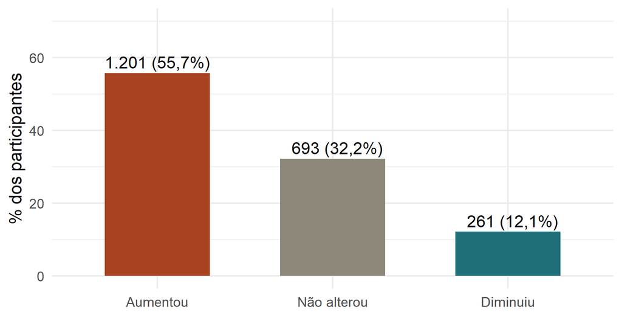

## **QUALITATIVAS (1/3): SOCIODEMOGRÁFICAS**

| **Variáveis** | **Mudança no tempo de preparo (pandemia)** **Aumentou** 1201 (56%) | **Mudança no tempo de preparo (pandemia)** **Não alterou** 693 (32%) | **Mudança no tempo de preparo (pandemia)** **Diminuiu** 261 (12%) | **Valor-p** | **Cramér** |  |  |
| --- | --- | --- | --- | --- | --- | --- | --- |
| Gênero<sup>F</sup> |  |  |  |  |  | 0,005 | 0,058 |
| Feminino | 919 (57%) | 480 (30%) | 203 (13%) |  |  |  |  |
| Masculino | 275 (51%) | 210 (39%) | 57 (11%) |  |  |  |  |
| Outro/NR | 7 (64%) | 3 (27%) | 1 (9,1%) |  |  |  |  |
| Raça/cor<sup>Q</sup> |  |  |  | 0,101 | 0,050 |  |  |
| Branca | 777 (58%) | 418 (31%) | 151 (11%) |  |  |  |  |
| Outras/NI | 41 (61%) | 20 (30%) | 6 (9,0%) |  |  |  |  |
| Parda | 300 (52%) | 200 (35%) | 76 (13%) |  |  |  |  |
| Preta | 83 (50%) | 55 (33%) | 28 (17%) |  |  |  |  |
| Região<sup>Q</sup> |  |  |  | <0,001 | 0,080 |  |  |
| Centro-oeste | 114 (53%) | 77 (35%) | 26 (12%) |  |  |  |  |
| Nordeste | 156 (58%) | 65 (24%) | 47 (18%) |  |  |  |  |
| Norte | 159 (52%) | 107 (35%) | 39 (13%) |  |  |  |  |
| Sudeste | 486 (54%) | 320 (35%) | 101 (11%) |  |  |  |  |
| Sul | 286 (62%) | 124 (27%) | 48 (10%) |  |  |  |  |
| Escolaridade<sup>Q</sup> |  |  |  | <0,001 | 0,090 |  |  |
| Até Médio | 376 (50%) | 255 (34%) | 117 (16%) |  |  |  |  |
| Ensino Superior Completo | 212 (51%) | 150 (36%) | 54 (13%) |  |  |  |  |
| Pós-graduação | 605 (62%) | 281 (29%) | 88 (9,0%) |  |  |  |  |
| Renda familiar<sup>Q</sup> |  |  |  | <0,001 | 0,098 |  |  |
| até R$ 1254,00 | 111 (45%) | 90 (37%) | 44 (18%) |  |  |  |  |
| entre R$ 1.255 - R$ 8.640 | 649 (53%) | 422 (34%) | 159 (13%) |  |  |  |  |
| mais de R$ 8.640 | 441 (65%) | 181 (27%) | 58 (8,5%) |  |  |  |  |

<sup>Q</sup> qui-quadrado · <sup>F</sup> exato de Fisher (Monte Carlo) · roxo = valor-p menor que 0,05 ou casa influente (resíduo padronizado maior que 1,96 em módulo) · Cramér = intensidade (0 a 1)

## **QUALITATIVAS (2/3): PANDEMIA, TRABALHO E HÁBITOS DE SAÚDE**

| **Variáveis** | **Mudança no tempo de preparo (pandemia)** **Aumentou** 1201 (56%) | **Mudança no tempo de preparo (pandemia)** **Não alterou** 693 (32%) | **Mudança no tempo de preparo (pandemia)** **Diminuiu** 261 (12%) | **Valor-p** | **Cramér** |  |  |
| --- | --- | --- | --- | --- | --- | --- | --- |
| Isolamento social<sup>Q</sup> |  |  |  |  |  | <0,001 | 0,118 |
| Não | 470 (49%) | 360 (38%) | 122 (13%) |  |  |  |  |
| Sim | 731 (61%) | 333 (28%) | 139 (12%) |  |  |  |  |
| Trabalha<sup>Q</sup> |  |  |  | 0,587 | 0,022 |  |  |
| Não | 314 (55%) | 193 (34%) | 65 (11%) |  |  |  |  |
| Sim | 887 (56%) | 500 (32%) | 196 (12%) |  |  |  |  |
| COVID-19<sup>Q</sup> |  |  |  | 0,610 | 0,021 |  |  |
| Não | 885 (56%) | 502 (32%) | 185 (12%) |  |  |  |  |
| Sim | 316 (54%) | 191 (33%) | 76 (13%) |  |  |  |  |
| Dificuldade financeira<sup>Q</sup> |  |  |  | <0,001 | 0,082 |  |  |
| Não | 994 (56%) | 576 (33%) | 191 (11%) |  |  |  |  |
| Sim | 207 (53%) | 117 (30%) | 70 (18%) |  |  |  |  |
| Consulta nutricionista<sup>Q</sup> |  |  |  | 0,077 | 0,049 |  |  |
| Não | 964 (55%) | 558 (32%) | 225 (13%) |  |  |  |  |
| Sim | 237 (58%) | 135 (33%) | 36 (8,8%) |  |  |  |  |
| Cigarro<sup>Q</sup> |  |  |  | 0,135 | 0,043 |  |  |
| Não | 1.144 (56%) | 664 (32%) | 242 (12%) |  |  |  |  |
| Sim | 57 (54%) | 29 (28%) | 19 (18%) |  |  |  |  |

<sup>Q</sup> qui-quadrado · <sup>F</sup> exato de Fisher (Monte Carlo) · roxo = valor-p menor que 0,05 ou casa influente (resíduo padronizado maior que 1,96 em módulo) · Cramér = intensidade (0 a 1)

## **QUALITATIVAS (3/3): SAÚDE EMOCIONAL**

| **Variáveis** | **Mudança no tempo de preparo (pandemia)** **Aumentou** 1201 (56%) | **Mudança no tempo de preparo (pandemia)** **Não alterou** 693 (32%) | **Mudança no tempo de preparo (pandemia)** **Diminuiu** 261 (12%) | **Valor-p** | **Cramér** |  |  |
| --- | --- | --- | --- | --- | --- | --- | --- |
| Ansiedade<sup>Q</sup> |  |  |  |  |  | <0,001 | 0,150 |
| Não | 623 (56%) | 401 (36%) | 85 (7,7%) |  |  |  |  |
| Sim | 578 (55%) | 292 (28%) | 176 (17%) |  |  |  |  |
| Depressão<sup>Q</sup> |  |  |  | <0,001 | 0,096 |  |  |
| Não | 1.019 (56%) | 593 (33%) | 194 (11%) |  |  |  |  |
| Sim | 182 (52%) | 100 (29%) | 67 (19%) |  |  |  |  |
| Insônia<sup>Q</sup> |  |  |  | 0,006 | 0,069 |  |  |
| Não | 1.049 (56%) | 605 (32%) | 209 (11%) |  |  |  |  |
| Sim | 152 (52%) | 88 (30%) | 52 (18%) |  |  |  |  |
| Enxaqueca<sup>Q</sup> |  |  |  | 0,062 | 0,051 |  |  |
| Não | 1.027 (56%) | 602 (33%) | 211 (11%) |  |  |  |  |
| Sim | 174 (55%) | 91 (29%) | 50 (16%) |  |  |  |  |

<sup>Q</sup> qui-quadrado · <sup>F</sup> exato de Fisher (Monte Carlo) · roxo = valor-p menor que 0,05 ou casa influente (resíduo padronizado maior que 1,96 em módulo) · Cramér = intensidade (0 a 1)

## **INTENSIDADE DAS ASSOCIAÇÕES (V DE CRAMÉR)**

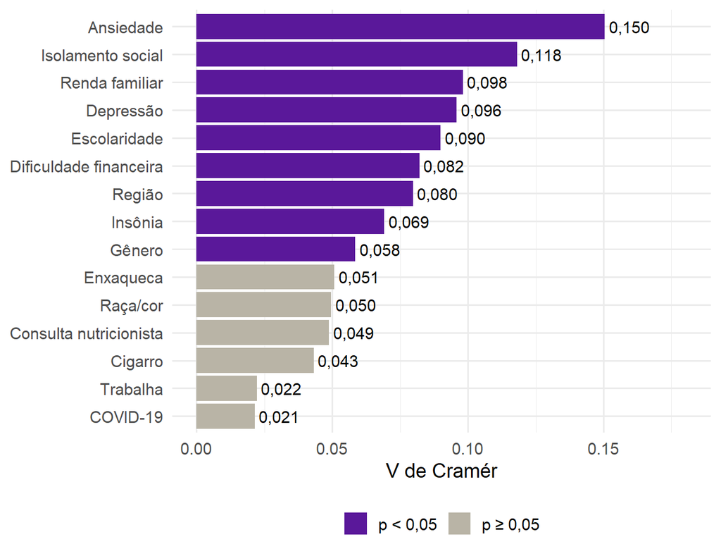

**9 de 15** variáveis qualitativas se associaram à resposta (p < 0,05), mas com intensidade **baixa** (V máx. = 0,150).

## **QUANTITATIVAS: DIAGNÓSTICOS**

| Variável | Shapiro-Wilk, p (Aumentou / Não alterou / Diminuiu) | Levene, p | Teste de médias |
| --- | --- | --- | --- |
| Idade (anos) | < 0,001 / < 0,001 / < 0,001 | < 0,001 | ANOVA de Welch |
| Peso (kg) | < 0,001 / < 0,001 / < 0,001 | 0,001 | ANOVA de Welch |
| Altura (m) | < 0,001 / < 0,001 / < 0,001 | 0,329 | ANOVA usual |
| IMC (kg/m²) | < 0,001 / < 0,001 / < 0,001 | 0,015 | ANOVA de Welch |

Normalidade rejeitada nos grupos, mas com n grande vale o TCL. Variâncias avaliadas por **Levene** (dados não normais): se diferentes, **ANOVA de Welch**.

## **QUANTITATIVAS: TABELA FINAL**

| **Variáveis** | **Mudança no tempo de preparo (pandemia)** **Aumentou** 1201 (56%) | **Mudança no tempo de preparo (pandemia)** **Não alterou** 693 (32%) | **Mudança no tempo de preparo (pandemia)** **Diminuiu** 261 (12%) | **Valor-p** | **Comparações Múltiplas** |  |  |
| --- | --- | --- | --- | --- | --- | --- | --- |
| Idade (anos)<sup>W</sup> | 35,36 (12,41) | 35,64 (13,17) | 30,39 (10,52) |  |  | <0,001 | Aumentou = a Não alterou = a Diminuiu = b |
| Peso (kg)<sup>W</sup> | 69,72 (15,13) | 71,21 (16,70) | 70,24 (17,65) | 0,155 | Aumentou = a Não alterou = a Diminuiu = a |  |  |
| Altura (m)<sup>A</sup> | 1,65 (0,08) | 1,66 (0,09) | 1,65 (0,09) | 0,231 | Aumentou = a Não alterou = a Diminuiu = a |  |  |
| IMC (kg/m²)<sup>W</sup> | 25,43 (4,81) | 25,76 (5,33) | 25,64 (5,69) | 0,395 | Aumentou = a Não alterou = a Diminuiu = a |  |  |

Média (desvio padrão) · <sup>A</sup> ANOVA usual · <sup>W</sup> ANOVA de Welch · letras iguais = sem diferença (Tukey ou Games-Howell, 5%) · roxo = valor-p menor que 0,05

## **IDADE E ANTROPOMETRIA POR GRUPO**

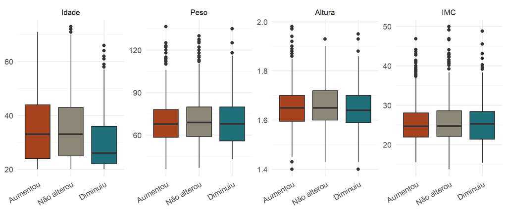

## **PRINCIPAIS RESULTADOS**

**Associadas (p < 0,05):** Gênero, Região, Isolamento social, Renda familiar, Escolaridade, Dificuldade financeira, Ansiedade, Depressão, Insônia; e, entre as quantitativas, Idade (anos).

**Sem evidência de associação:** Raça/cor, Trabalha, COVID-19, Consulta nutricionista, Cigarro, Enxaqueca, Peso (kg), Altura (m), IMC (kg/m²).

- **Proporção maior de aumento:** (casas em roxo) isolamento social, renda alta, pós-graduação e região Sul.
- **Proporção maior de diminuição:** ansiedade, depressão, insônia, dificuldade financeira, renda baixa, até ensino médio e Nordeste.
- **Idade:** quem diminuiu é mais jovem (média de 30,4 contra 35,4 e 35,6 anos).
- **Gênero:** mulheres aumentaram mais (57,4% contra 50,7%); homens, mais “não alterou” (38,7% contra 30,0%).

# **CONCLUSÃO**

## **CONCLUSÃO**

**Objetivo:** avaliar a associação entre `Tempo_Preparo_Pandemia` e as demais variáveis. Entre 2.155 adultos, **55,7%** aumentaram o tempo de preparo e **12,1%** diminuíram.

- **10 de 19** variáveis se associaram à resposta (Gênero, Região, Isolamento social, Renda familiar, Escolaridade, Dificuldade financeira, Ansiedade, Depressão, Insônia, Idade (anos)); peso, altura e IMC não. Os efeitos são **pequenos** (V máx. = 0,150).
- **Leitura possível:** isolamento social, renda e escolaridade maiores se associam a mais aumento do tempo de preparo (talvez por mais tempo em casa e mais recursos); ansiedade, depressão, insônia, dificuldade financeira e menor renda se associam a uma proporção maior de redução. São hipóteses, não causas.
- **Cuidados:** com Bonferroni (19 testes, α = 0,0026) Gênero e Insônia deixam de ser significativas; amostra online (74% mulheres, 45% pós-graduados), autorrelato e corte transversal.
- **Limites:** cada variável foi analisada isoladamente, então fatores correlacionados podem se sobrepor. Um modelo multivariado seria o próximo passo.